# Welcome to StatPREP

## Three styles

Three different audiences in one.

1. Students, seeing data-centric lessons
2. Instructors, learning some new tools and styles
3. Budding data scientists, learning tools for doing data science

## Results from the survey

1. I am willing to take this survey. 94% (sampling bias)
2. Institution type: two thirds from two-year colleges. One from high school. Remaining from 4-year institutions.
3. Everyone responding has taught introductory statistics.

## Results from the survey

1. What coursework did we take in graduate school?

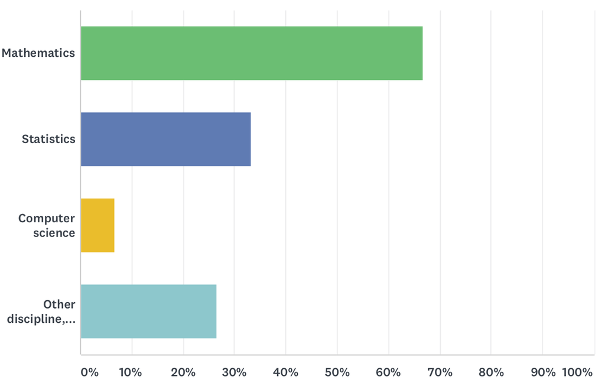

## Results from the survey

1. Almost half have taken applied stats coursework.
2. Almost half "conduct statistical analyses of data outside of teaching (e.g., for your own research, consulting, etc.)"

## Results from the survey

1. Computing used

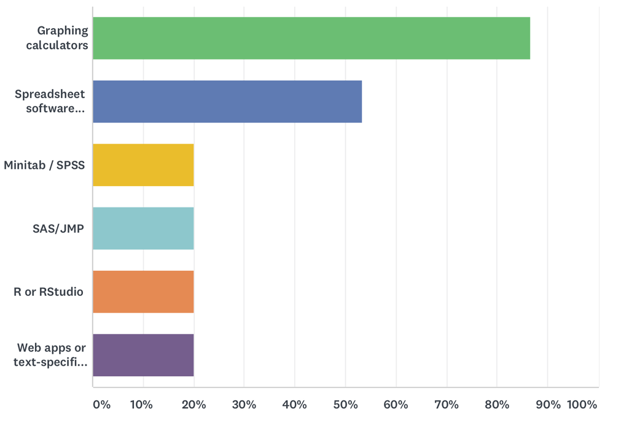

## Results from the survey

1. We lack
   - Access to real data: 50%
   - Personal experience handling large data sets: 55%
   - Technology infrastructure for large data sets: 45%
   - Graphing ability: 60% [ci at 95%: 40-80%]
2. Obstacles to making changes
   - Not enough personal time: 70%
   - Student characteristics: 55%
   - Technology constraints: 60% [ci at 95%: 40-80%]
   - Department or institutional constraints: 30%

> *"Too many students can't take the intro stats course, and hence graduate, because of the burden of "intermediate algebra" prerequisite."*

## Results from the survey

Areas of consensus

- Students learn statistics more effectively by learning fewer topics in greater depth than learning more topics in less depth. 95% agree or strongly agree
- The many methods covered in introductory statistics can be reduced to a small set of common principles. 85% agree
- Rules of probability should be included in an introductory statistics course. 85% agree.
- Students learn statistics more effectively from a good lecture than from a good activity. 80% disagree or strongly disaggree

## Results from the survey

More areas of concesus

- Algebraic formulas are the best method to learn statistics. 100% disagree
- Students learn statistics better by understanding how to express concepts with algebra. 85% disagree
- Computing offers a framework for understanding statistical theory that is as legitimate as the theory based on probability rules and algebra. 80% agree
- Students should learn how to read statistical tables of theoretical distributions (e.g., t-table, F-table). 80% disagree

## About tables …

GAISE College report (p. 24)

> Drills with z-, t-, χ2, and F-tables. These skills are no longer necessary and do not reflect modern statistical practice. Since statistical software produces a p-value as part of performing a hypothesis test, a shift from finding p-values to interpreting p-values in context is appropriate.

## p value quiz

ASA statement:

> *Underpinning many published scientific conclusions is the concept of “statistical significance,” typically assessed with an index called the p-value. While the p-value can be a useful statistical measure, it is commonly misused and misinterpreted.*

## Quiz: Agree or disagree?

1. P-values can indicate how incompatible the data are with a **specified statistical model**.
2. P-values do not measure the probability that the studied hypothesis is true, or the probability that the data were produced by random chance alone.
3. A p-value, or statistical significance, does not measure the size of an effect or the importance of a result.
4. By itself, a p-value does not provide a good measure of evidence regarding a model or hypothesis.

[Answers here](https://amstat.tandfonline.com/doi/pdf/10.1080/00031305.2016.1154108?needAccess=true)

## Theory or practice?

Is statistics …

- an area of theory (like group theory or number theory or graph theory)?
- a practical tool?

Insofar as statistics is a practical tool, the stat education community some catching up to do.

## 1880s Galton and Benz

- 1885 Karl Benz designs 4-stroke engine for use in his automobile
- 1888 Francis Galton introduces the "co-relation" coefficient

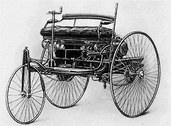

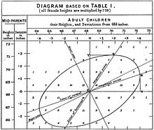

## 1908 Gossett and Ford

- First Model T off Henry Ford's production line
- William Gossett's t statistic

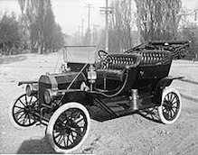

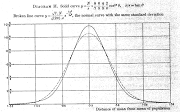

## 1920s

- 1925 ANOVA appears in Fisher's *Statistical Methods for Research Workers*
- 1927 Ford Model A enters production

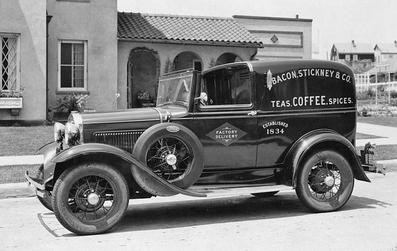

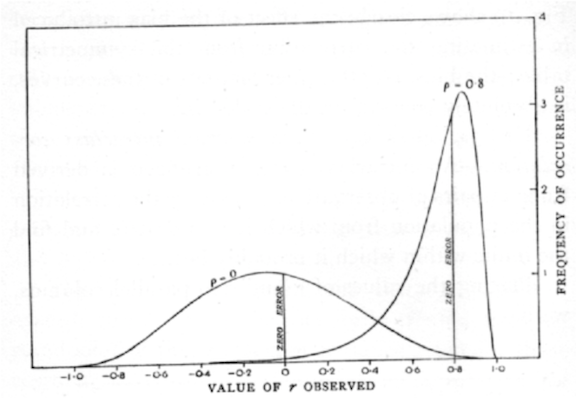

## Orientation to the workshop agenda